# Week1: Linear Models

# Objective

This homework sheet will help reviewing the basic concepts associated with linear regression models. Please review the lectures, suggested readings, and additional resources **before** getting started on the HW

**Some questions in this assignment will require you to conduct independent research beyond the material covered in the recorded content.**

**Questions**

This homework is divided into two main parts. First, a conceptual component will review the basic concepts related to linear models. The second part of the homework is mostly intended to be a brief introduction to fitting and analyzing linear models in Python. Several of these questions are modified from James et al. (2021).

Marks Distribution

| Question | Marks |
| --- | --- |
| 1 | 1 |
| 2a | 0.25 |
| 2b | 0.25 |
| 2c | 0.25 |
| 2d | 0.25 |
| 3a | 0.25 |
| 3b | 0.25 |
| 3c | 0.25 |
| 3d | 0.25 |
| 4a.i | 0.25 |
| 4a.ii | 0.25 |
| 4a.iii | 0.25 |
| 4a.iv | 0.50 |
| 4a.v | 0.25 |
| 4a.vi | 0.50 |
| 4b | 0.50 |
| 4c | 0.50 |
| 5a | 0.25 |
| 5b | 0.25 |
| 5c.i | 0.25 |
| 5c.ii | 0.25 |
| 5c.iii | 0.25 |
| 5d | 0.25 |
| 5e | 0.25 |
| 5f | 0.25 |
| 6a | 0.25 |
| 6b | 0.25 |
| 6c | 0.25 |
| 6d | 0.25 |
| 6e | 0.25 |
| 6f | 0.25 |
| 6g | 0.50 |
| 6h | 0.50 |
| 6i | 0.50 |
| 6j | 0.50 |
| 7a | 0.25 |
| 7b | 0.50 |
| 7c | 0.50 |
| 7d | 0.25 |
| 7e | 0.25 |
| 7f | 0.25 |
| 7g | 0.50 |
| 8 | 1 |

The following website has access to the relevant datasets from the recommended textbook: https://book.huihoo.com/introduction-to-statistical-learning/data.html

# Conceptual

## Question 1

Describe the null hypotheses to which the *p*-values given in the table (see below). Explain what conclusions you can draw based on these p-values. Your explanation should be phrased in terms of sales, TV, radio, and newspaper, rather than in terms of the coefficients of the linear model.

|  | Coefficient | Std. error | t-statistics | p-value |
| --- | --- | --- | --- | --- |
| Intercept | 2.939 | 0.3119 | 9.42 | <0.0001 |
| TV | 0.046 | 0.0014 | 32.81 | <0.0001 |
| Radio | 0.189 | 0.0086 | 21.89 | <0.0001 |
| Newspaper | -0.001 | 0.0059 | -0.18 | 0.8599 |

Provide your answer in this Markdown cell

#### p-value:

1. The p-value of a predictor indicates whether it is significantly related to the response or not.
2. If the p-value is above a certain threshold such as 0.01 or 0.05 it indicates the absence of a relation between the predictor variable and the response. This suggests that the null hypothesis is true.
3. If the p-value is below the specified threshold, it is an indication to reject the null hypothesis and that there is a strong and significant relationship between the predictor variable and the response.

#### Null-hypothesis:

1. From the table it is observed that advertising on TV, radio and newspaper are the predictors whereas sales is the response and intercept is a constant that indicates the sales in the absence of any advertising.
2. Null-hypothesis for TV($H_{0}$) corresponds to coefficient of TV being zero($\beta_{TV}=0$). In other words it indicates that there is no relationship between the predictor TV and response sales in the presence of variables radio,newspaper and intercept.
3. Null-hypothesis for Radio($H_{0}$) corresponds to coefficient of Radio being zero($\beta_{Radio}=0$). In other words it indicates that there is no relationship between the predictor Radio and response sales in the presence of variables tv,newspaper and intercept.
4. Null-hypothesis for Newspaper($H_{0}$) corresponds to coefficient of Newspaper being zero($\beta_{Newspaper}=0$). In other words it indicates that there is no relationship between the predictor Newspaper and response sales in the presence of variables tv,radio and intercept.
5. Null-hypothesis for Intercept($H_{0}$) corresponds to coefficient of Intercept being zero($\beta_{Intercept}=0$). In other words it indicates that there are no sales in the absence of variables tv,radio and newspaper.

#### Conclusions based on the given table:

1. The p-value of the predictor variable advertising on TV is <0.0001 which is less than the threshold 0.05. It indicates the rejection of null hypothesis. Thus, there is a significant relationship between the response sales and the predictor advertising on TV in the presence of variables radio,newspaper and intercept. $\beta_{TV}\neq0$
2. The p-value of the predictor variable advertising on Radio is <0.0001 which is less than the threshold 0.05. It indicates the rejection of null hypothesis. Thus, there is a significant relationship between the response sales and the predictor advertising on Radio in the presence of variables tv,newspaper and intercept. $\beta_{Radio}\neq0$
3. The p-value of the predictor variable advertising on Newspaper is 0.8599 which is greater than the threshold 0.05. It indicates that the null hypothesis is true. Thus, there is no noticeable relationship between the response sales and the predictor advertising on Newspaper in the presence of variables tv,radio and intercept. $\beta_{Newspaper}=0$
4. The p-value for the intercept is <0.0001 which is less than the threshold 0.05. It indicates the rejection of null-hypothesis. Thus, there are non-zero sales in the absence of variables tv, radio and newspaper. $\beta_{Intercept}\neq0$

## Question 2

Assume that you collected a dataset of 100 observations containing a single predictor and a quantitative response. Then, you decided to fit a

(i) linear regression model to the data, as well as a separate

(ii) cubic regression, i.e. $Y = β_{0} + β_{1}X^{1} + β_{2}X^{2} + β_{3}X^{3} + ϵ$

### a) Suppose that the true relationship between $X$ and $Y$ is linear, i.e. $Y = β_{0} + β_{1}X + ϵ$. Consider the training residual sum of squares (*RSS*) for the linear regression, and also the training *RSS* for the cubic regression. Would we expect one to be lower than the other, would we expect them to be the same, or is there not enough information to tell? Justify your answer

Provide your answer in this Markdown cell

1. The training residual sum of squares(RSS) for the cubic regression is expected to be lower than that for the linear regression because cubic model is more flexible than the linear model.
2. The cubic regression model can fit the training data very well and reduces the training RSS error to a greater extent compared to the linear model.
3. Thus, training RSS for cubic regression is lower than that for the linear regression.

### b) Answer part (a) using the test *RSS* rather than training *RSS*.

Provide your answer in this Markdown cell

1. The cubic regression model fits the training data too well as it is more flexible. This phenomenon is called overfitting. The cubic model only learns the training data and is not generalized.
2. The linear model on the other hand is more generalized and has less variance compared to the cubic model. Hence, it performs better and has lower test RSS since the true relationship between X and Y is linear.
3. Thus, test RSS for linear regression is lower than that for the cubic regression.

### c) Suppose that the true relationship between $X$ and $Y$ is not linear. However, we don’t know how far it is from linear. Consider the training *RSS* for the linear regression, and also the training *RSS* for the cubic regression. Would we expect one to be lower than the other, would we expect them to be the same, or is there not enough information to tell? Justify your answer.

Provide your answer in this Markdown cell

1. The training RSS for cubic regression is lower than that for linear regression as cubic model is more flexible than the linear model even if we are not aware of the degree of non-linearity.
2. The cubic model learns the training data to a greater extent compared to the linear model.
3. Hence, the training RSS for cubic regression is lower than that for linear regression even if we are not provided information about the degree of non-linearity in the true relationship between X and Y

### d) Answer (c) using test *RSS* rather than training *RSS.*

Provide your answer in this Markdown cell

1. To determine which test RSS is lower, we need more information regarding the degree of non-linearity in the true relationship between X and Y.
2. If the true relationship is closer to a linear relation between X and Y then the linear regression test RSS is lower than the cubic regression test RSS.
3. If the true relationship is closer to a cubic relation between X and Y then the cubic regression test RSS is lower than the linear regression test RSS.

## Question 3

### a) Discuss the implications that uncertainty in $X$ would have on parameter estimates based on linear regression models. Should we care about error in $X$ when fitting OLS regressions?

Provide your answer in this Markdown cell

#### Implications on parameter estimates because of uncertainty in X:

1. Uncertainty in X can add bias to the parameters-intercept and predictor variables. Moreover, it can add potential variance terms to the parameters.
2. This leads to inaccurate parameter estimates that effect the predictions accuracy. This increases the width of confidence intervals for the parameter estimates.

#### Significance of error in X:

1. We should include the error in X when fitting OLS regressions because uncertainty in X causes inaccurate predictions by adding bias to the model.
2. We cannot capture the exact relationship between the predictors and the response if we ignore the error in X.

### b) Provide a brief discussion on the concept of regression dilution.

Provide your answer in this Markdown cell

1. Regression dilution refers to the concept where the linear regression parameter estimates are biased towards zero because of an error in the measurement of predictors or presence of uncertainty in the predictors
2. Regression dilution can occur because of the presence of variability in the predictors. This can happen because of imperfect data collection, instrument error and irreducible variability in the data.
3. Because of this measurement error in the predictors, the true relation between the predictors and response cannot be learnt by the model resulting in clipping or attenuation of parameter estimates i.e., biasing them towards zero.
4. Regression dilution can be addressed by careful measurements of variables and modern regression techniques that are robust to these kind of errors.

### c) Are there any linear regression models that account for uncertainty in $X$ and $Y$? Please do some independent research and cite your sources.

Provide your answer in this Markdown cell

1. Errors-in-Variables(EV) regression models account for the uncertainty in X and Y. They can take care of measurement errors in X and Y and improve the model accuracy.
2. Some of these models are Deming regression$^1$, orthogonal regression$^1$, Linear Structural Relations(LISREL) Models$^2$ and Instrumental Variables Regressions$^3$.

**Citations**

1. Errors in Variables in Panel Data" by Zvi Griliches and Jerry A. Hausman
2. Jöreskog, K. G. (1971). "Statistical analysis of sets of congeneric tests." Psychometrika, 36(2), 109-133
3. Angrist, J. D., & Krueger, A. B. (1991). "Does compulsory school attendance affect schooling and earnings?" The Quarterly Journal of Economics, 106(4), 979-1014

### d) Distinguish between least squares and maximum likelihood in the context of linear regression models

Provide your answer in this Markdown cell

1. The least squares method minimizes the residual sum of squares whereas maximum likelihood method maximizes the likelihood function.
2. The least squares method focuses on finding the line that fits the data well by minimizing the RSS whereas maximum likelihood estimation finds the parameter estimates using a probabilistic framework by maximizing the likelihood function.
3. The least squares method is unbiased whereas maximum likelihood method is unbiased in large sample sizes only. The maximum likelihood method is biased in small sample sizes.

# Applied

Please note that some of the questions outlined below make suggestions on potential functions to be used in the answers. Feel free to use any other function. These are just a reference.

## Question 4

This question involves the use of simple linear regression on the Auto data set.

### a) Use the " OLS() function " from " Statsmodels " library to perform a simple linear regression with " mpg " as the response and " horsepower" as the predictor. Use the "summary()" function to print the results. Then, answer the questions below:

Reference to Statsmodels library and ols :

https://www.statsmodels.org/dev/generated/statsmodels.regression.linear_model.OLS.html#generated-statsmodels-regression-linear-model-ols--page-root

```python
#IMPORT LIBRARIES
import numpy as np
import pandas as pd
import matplotlib.pyplot as plt
import statsmodels.api as sm
```

```python
#READ AUTO.CSV DATASET
org = pd.read_csv('./Auto.csv')
auto_df = org.copy()
auto_df.head()
```

|  | mpg | cylinders | displacement | horsepower | weight | acceleration | year | origin | name |
| --- | --- | --- | --- | --- | --- | --- | --- | --- | --- |
| 0 | 18.0 | 8 | 307.0 | 130 | 3504 | 12.0 | 70 | 1 | chevrolet chevelle malibu |
| 1 | 15.0 | 8 | 350.0 | 165 | 3693 | 11.5 | 70 | 1 | buick skylark 320 |
| 2 | 18.0 | 8 | 318.0 | 150 | 3436 | 11.0 | 70 | 1 | plymouth satellite |
| 3 | 16.0 | 8 | 304.0 | 150 | 3433 | 12.0 | 70 | 1 | amc rebel sst |
| 4 | 17.0 | 8 | 302.0 | 140 | 3449 | 10.5 | 70 | 1 | ford torino |

```python
auto_df.info()
```

```
<class 'pandas.core.frame.DataFrame'>
RangeIndex: 397 entries, 0 to 396
Data columns (total 9 columns):
 #   Column        Non-Null Count  Dtype
---  ------        --------------  -----
 0   mpg           397 non-null    float64
 1   cylinders     397 non-null    int64
 2   displacement  397 non-null    float64
 3   horsepower    397 non-null    object
 4   weight        397 non-null    int64
 5   acceleration  397 non-null    float64
 6   year          397 non-null    int64
 7   origin        397 non-null    int64
 8   name          397 non-null    object
dtypes: float64(3), int64(4), object(2)
memory usage: 28.0+ KB
```

```python
auto_df['horsepower'].unique() # there is '?' in the horsepower column
```

```
array(['130', '165', '150', '140', '198', '220', '215', '225', '190',
       '170', '160', '95', '97', '85', '88', '46', '87', '90', '113',
       '200', '210', '193', '?', '100', '105', '175', '153', '180', '110',
       '72', '86', '70', '76', '65', '69', '60', '80', '54', '208', '155',
       '112', '92', '145', '137', '158', '167', '94', '107', '230', '49',
       '75', '91', '122', '67', '83', '78', '52', '61', '93', '148',
       '129', '96', '71', '98', '115', '53', '81', '79', '120', '152',
       '102', '108', '68', '58', '149', '89', '63', '48', '66', '139',
       '103', '125', '133', '138', '135', '142', '77', '62', '132', '84',
       '64', '74', '116', '82'], dtype=object)
```

```python
hp_list = list(auto_df['horsepower'])
unwanted_indices = []
for idx,item in enumerate(hp_list):
    if item=='?':
        print(f'Index: {idx} and corresponding value: {item}')
        unwanted_indices.append(idx)
unwanted_indices
```

```
Index: 32 and corresponding value: ?
Index: 126 and corresponding value: ?
Index: 330 and corresponding value: ?
Index: 336 and corresponding value: ?
Index: 354 and corresponding value: ?
```

```
[32, 126, 330, 336, 354]
```

```python
#PERFORM PRE PROCESSING OF DATA IF REQUIRED ( OBSERVE THE DATASET AND ITS VALUES CAREFULLY)
auto_df['horsepower'] = pd.to_numeric(auto_df['horsepower'], errors='coerce')
auto_df = auto_df.dropna(subset=['horsepower'])
```

```python
Y = auto_df['mpg']
X = sm.add_constant(auto_df['horsepower'])

simple_line_reg = sm.OLS(Y,X).fit()

print(simple_line_reg.summary())
```

```
                            OLS Regression Results
==============================================================================
Dep. Variable:                    mpg   R-squared:                       0.606
Model:                            OLS   Adj. R-squared:                  0.605
Method:                 Least Squares   F-statistic:                     599.7
Date:                Wed, 03 Apr 2024   Prob (F-statistic):           7.03e-81
Time:                        01:21:00   Log-Likelihood:                -1178.7
No. Observations:                 392   AIC:                             2361.
Df Residuals:                     390   BIC:                             2369.
Df Model:                           1
Covariance Type:            nonrobust
==============================================================================
                 coef    std err          t      P>|t|      [0.025      0.975]
------------------------------------------------------------------------------
const         39.9359      0.717     55.660      0.000      38.525      41.347
horsepower    -0.1578      0.006    -24.489      0.000      -0.171      -0.145
==============================================================================
Omnibus:                       16.432   Durbin-Watson:                   0.920
Prob(Omnibus):                  0.000   Jarque-Bera (JB):               17.305
Skew:                           0.492   Prob(JB):                     0.000175
Kurtosis:                       3.299   Cond. No.                         322.
==============================================================================

Notes:
[1] Standard Errors assume that the covariance matrix of the errors is correctly specified.
```

```python
rse = np.sqrt(simple_line_reg.mse_resid)
rse
```

```
4.90575691954594
```

### i. Is there a relationship between the predictor and the response?

Provide your answer in this Markdown cell

Yes there is a relationship between the predictor horsepower and the response mpg because the p-value for horsepower is 0.000 indicating that the null hypothesis should be rejected. This tells us that there is a significant relationship between the predictor horsepower and the response mpg.

### ii. How strong is the relationship between the predictor and the response? Focus on the *RSE*, estimated $R^2$, and *slope.*

Provide your answer in this Markdown cell

1. The $R^2=0.606$ indicates that 60.6% of the variability in the response mpg is explained by the predictor horsepower.
2. The RSE is an estimate of the standard deviation($\sigma$) of $\epsilon$. Here $RSE=\sigma=4.906$ indicate that the difference between actual and predicted values of mpg is about 4.906.
3. The slope or the parameter estimate for horsepower is -0.1578. This indicates that the mpg and horsepower are inversely related.
4. Thus we can conclude that there is moderately strong relationship between the predictor horsepower and the response mpg in a negative trend.

### iii. Is the relationship between the predictor and the response positive or negative?

Provide your answer in this Markdown cell

The relationship between the predictor horsepower and the response mpg is negative as the slope is -0.1578 which is a negative quantity. A one unit rise in horsepower decreases the mpg by 0.1578 units.

### iv. What is the predicted mpg associated with a **horsepower** of **98**? What are the associated 95% confidence and prediction intervals?

```python
# BEGIN SOLUTION
new_hp_array = pd.DataFrame({'const':1, 'horsepower':[98]})
mpg_prediction = simple_line_reg.get_prediction(new_hp_array)

predicted_mpg = mpg_prediction.predicted_mean
confidence_interval = mpg_prediction.conf_int(alpha=0.05)
prediction_interval = mpg_prediction.conf_int(obs=True, alpha=0.05)

print(f'The predicted mpg associated with the horsepower 98 is {(predicted_mpg[0])}\n')
print(f"Confidence interval is {confidence_interval[0]}\n")
print(f'Prediction interval is {prediction_interval[0]}\n')
# END SOLUTION
```

```
The predicted mpg associated with the horsepower 98 is 24.46707715251242

Confidence interval is [23.97307896 24.96107534]

Prediction interval is [14.80939607 34.12475823]
```

Provide your comments in this Markdown cell

1. The predicted mpg value for a horsepower of 98 is 24.46707715251242
2. The 95% confidence interval is [23.97307896, 24.96107534]
3. The 95% prediction interval is [14.80939607, 34.12475823]

### V. **Now, please briefly explain the main use of inverse predictions. List at least two practical examples.**

Provide your comments in this Markdown cell

Inverse predictions are mainly used to predict the predictor variables using the known response values. Examples include:-

> 1. In economics, variables such as stock price, inflation rates can be found out from the known response 'GDP' using inverse prediction technique.
> 2. In medical research, variables such as hormone level,sugar level, body temperature can be found out from the known response 'insulin level' using inverse prediction technique.

### vi. use " fsolve function from scipy " (or any function of your preference) to infer horsepower from the same mpg value predicted in (**iv**). Comment on your results.

Link to fsolve from scipy library:

https://docs.scipy.org/doc/scipy/reference/generated/scipy.optimize.fsolve.html

```python
# BEGIN SOLUTION

from scipy.optimize import fsolve

def lin_reg_equation(horsepower,constant,slope,mpg):
    return constant + slope*horsepower - mpg

constant = simple_line_reg.params['const']
slope = simple_line_reg.params['horsepower']
mpg = predicted_mpg # value obtained in (iv)
guess_horsepower = 1000

solved_hp = fsolve(lin_reg_equation,x0=guess_horsepower,args=(constant, slope, mpg))
print(f"The horsepower obtained from fsolve function is {solved_hp[0]}")
# END SOLUTION
```

```
The horsepower obtained from fsolve function is 98.0
```

1. The horsepower obtained from the known mpg value predicted in (iv) using the fsolve method is same as the true value of horsepower(98).
2. This indicates that the predicted mpg value in (iv) associated with the true horsepower value(98) is correct.

### b) Plot the response and the predictor. Use the `lmplot()` function from seaborn to display the least squares regression line.

Link to lmplot() in seaborn:

https://seaborn.pydata.org/archive/0.11/tutorial/regression.html#:~:text=(%22tips%22)-,Functions%20to%20draw%20linear%20regression%20models,much%20of%20their%20core%20functionality.

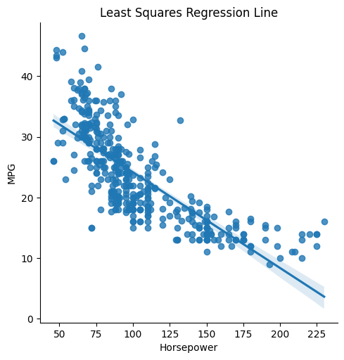

```python
# BEGIN SOLUTION
import seaborn as sns


sns.lmplot(x='horsepower', y='mpg', data=auto_df)
plt.title("Least Squares Regression Line")
plt.xlabel('Horsepower')
plt.ylabel('MPG')

plt.show()
# END SOLUTION
```

### c) Use the `plot_fit` function from statsmodels library to produce diagnostic plots of the least squares regression fit. Comment on any problems you see with the fit.

Link to plot_fit:

https://www.statsmodels.org/dev/generated/statsmodels.graphics.regressionplots.plot_fit.html

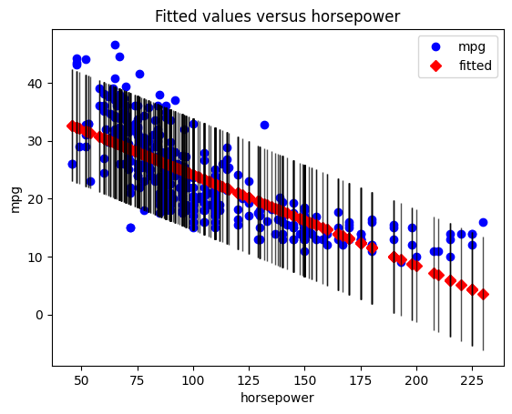

```python
# BEGIN SOLUTION
from statsmodels.graphics.regressionplots import plot_fit

plot_fit(simple_line_reg,1)
plt.show()
# END SOLUTION
```

1. The scatter plot indicates a slight non-linear pattern as it has a curvature in it but we fitted a linear model. A non-linear model might learn the training data in a better way by fitting more number of points.
2. The spread of the residuals or the width of the bands are equal for each band. This indicates homoscedasticity.

## Question 5

This question involves the use of multiple linear regression on the Auto data set. Read the dataset first:

### a) Produce a scatterplot matrix using pairplot() from seaborn library which includes all of the variables in the data set

Link to pairplot: https://seaborn.pydata.org/generated/seaborn.pairplot.html

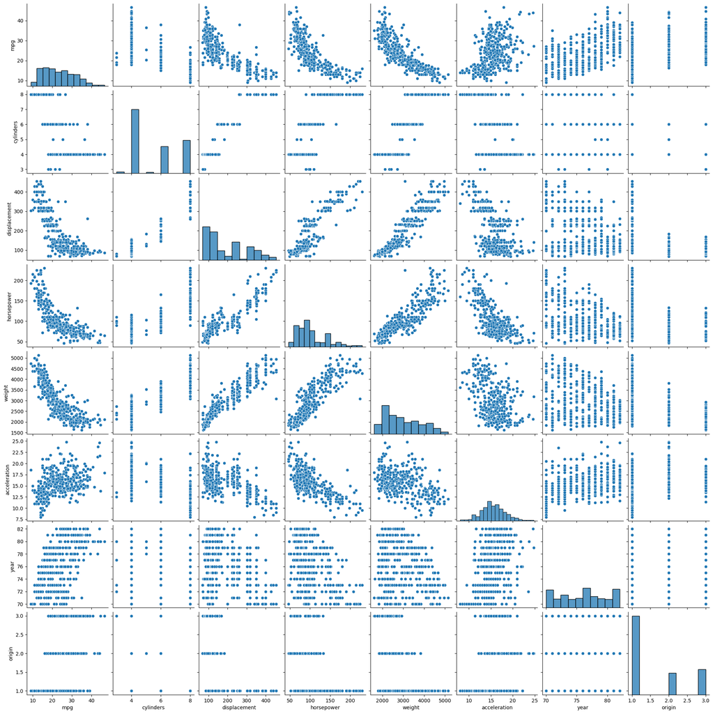

```python
# BEGIN SOLUTION
sns.pairplot(auto_df)
plt.show()
# END SOLUTION
```

### b) Compute the matrix of correlations between the variables using the function `corr()`in pandas on the dataframe also plot the corresponding correlation matrix using `heatmap` function in seaborn

Links:

Corr() : https://pandas.pydata.org/docs/reference/api/pandas.DataFrame.corr.html

Heatmap : https://seaborn.pydata.org/generated/seaborn.heatmap.html

```python
# BEGIN SOLUTION

numeric_df = auto_df.select_dtypes(include=['float64','int64']) # we are selecting only numeric columns and not the name(string) column
matrix_of_correlations = numeric_df.corr()
matrix_of_correlations
# END SOLUTION
```

|  | mpg | cylinders | displacement | horsepower | weight | acceleration | year | origin |
| --- | --- | --- | --- | --- | --- | --- | --- | --- |
| mpg | 1.000000 | -0.777618 | -0.805127 | -0.778427 | -0.832244 | 0.423329 | 0.580541 | 0.565209 |
| cylinders | -0.777618 | 1.000000 | 0.950823 | 0.842983 | 0.897527 | -0.504683 | -0.345647 | -0.568932 |
| displacement | -0.805127 | 0.950823 | 1.000000 | 0.897257 | 0.932994 | -0.543800 | -0.369855 | -0.614535 |
| horsepower | -0.778427 | 0.842983 | 0.897257 | 1.000000 | 0.864538 | -0.689196 | -0.416361 | -0.455171 |
| weight | -0.832244 | 0.897527 | 0.932994 | 0.864538 | 1.000000 | -0.416839 | -0.309120 | -0.585005 |
| acceleration | 0.423329 | -0.504683 | -0.543800 | -0.689196 | -0.416839 | 1.000000 | 0.290316 | 0.212746 |
| year | 0.580541 | -0.345647 | -0.369855 | -0.416361 | -0.309120 | 0.290316 | 1.000000 | 0.181528 |
| origin | 0.565209 | -0.568932 | -0.614535 | -0.455171 | -0.585005 | 0.212746 | 0.181528 | 1.000000 |

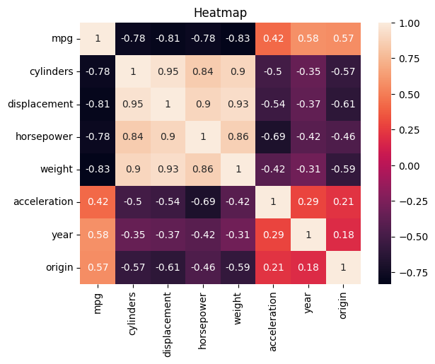

```python
sns.heatmap(matrix_of_correlations,annot=True)
plt.title('Heatmap')
plt.show()
```

Provide your comments in this Markdown cell

1. The variable cylinders is strongly positively correlated to the variables displacement, horsepower and weight.
2. The variable horsepower is negatively correlated to the variables acceleration, year and origin.

### c) Use the `ols()` function from statsmodels library to perform a multiple linear regression with mpg as the response and all other variables except name as the predictors. Use the `summary()` function from statsmodels to print the results. Use the questions below to comment on the output.

Reference to Statsmodels library and ols :

https://www.statsmodels.org/dev/generated/statsmodels.regression.linear_model.OLS.html#generated-statsmodels-regression-linear-model-ols--page-root

Links to summary:

https://www.statsmodels.org/devel/generated/statsmodels.regression.linear_model.OLSResults.summary.html

```python
# BEGIN SOLUTION
Y = auto_df['mpg']
X = sm.add_constant(auto_df.drop(['mpg','name'], axis=1))

multi_lin_reg = sm.OLS(Y,X).fit()

print(multi_lin_reg.summary())
# END SOLUTION
```

```
                            OLS Regression Results
==============================================================================
Dep. Variable:                    mpg   R-squared:                       0.821
Model:                            OLS   Adj. R-squared:                  0.818
Method:                 Least Squares   F-statistic:                     252.4
Date:                Wed, 03 Apr 2024   Prob (F-statistic):          2.04e-139
Time:                        02:56:12   Log-Likelihood:                -1023.5
No. Observations:                 392   AIC:                             2063.
Df Residuals:                     384   BIC:                             2095.
Df Model:                           7
Covariance Type:            nonrobust
================================================================================
                   coef    std err          t      P>|t|      [0.025      0.975]
--------------------------------------------------------------------------------
const          -17.2184      4.644     -3.707      0.000     -26.350      -8.087
cylinders       -0.4934      0.323     -1.526      0.128      -1.129       0.142
displacement     0.0199      0.008      2.647      0.008       0.005       0.035
horsepower      -0.0170      0.014     -1.230      0.220      -0.044       0.010
weight          -0.0065      0.001     -9.929      0.000      -0.008      -0.005
acceleration     0.0806      0.099      0.815      0.415      -0.114       0.275
year             0.7508      0.051     14.729      0.000       0.651       0.851
origin           1.4261      0.278      5.127      0.000       0.879       1.973
==============================================================================
Omnibus:                       31.906   Durbin-Watson:                   1.309
Prob(Omnibus):                  0.000   Jarque-Bera (JB):               53.100
Skew:                           0.529   Prob(JB):                     2.95e-12
Kurtosis:                       4.460   Cond. No.                     8.59e+04
==============================================================================

Notes:
[1] Standard Errors assume that the covariance matrix of the errors is correctly specified.
[2] The condition number is large, 8.59e+04. This might indicate that there are
strong multicollinearity or other numerical problems.
```

#### i. Is there a significant association between the predictors and the response?

Provide your answer in this Markdown cell

Yes there is a significant association between some predictors and the response mpg.

#### ii. Which predictors appear to have a statistically significant relationship to the response?

Provide your answer in this Markdown cell

The predictors displacement, weight, year and origin have a statistically significant relationship to the response mpg.

#### iii. What does the coefficient for the year variable suggest?

Provide your answer in this Markdown cell

The coefficient of year is 0.7508. This indicates that estimated mpg rises by 0.7508 units for every one-unit increase in the predictor year when the remaining variables are constant.

### d) Use the `plot_fit ()` function from statsmodels to produce diagnostic plots of the linear regression fit. Again, feel free to use any other package or function to create these plots. Comment on any problems you see with the fit. Do the residual plots suggest any unusually large outliers? Does the leverage plot identify any observations with unusually high leverage?

Link to plot_fit:

https://www.statsmodels.org/dev/generated/statsmodels.graphics.regressionplots.plot_fit.html

Link to residual plots:

https://www.statsmodels.org/dev/generated/statsmodels.graphics.regressionplots.plot_leverage_resid2.html

### using plot_fit()

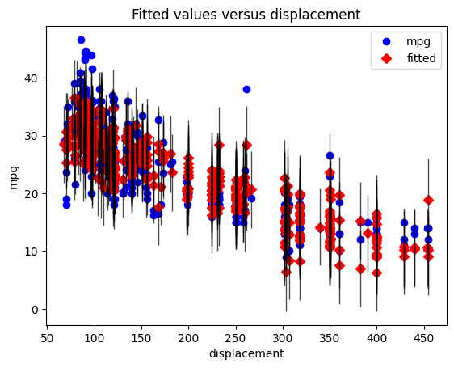

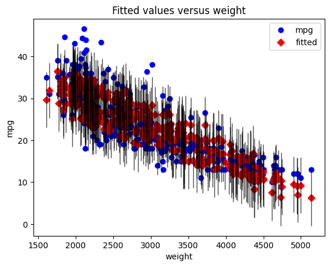

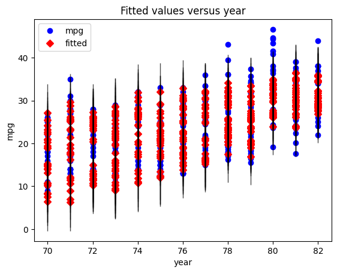

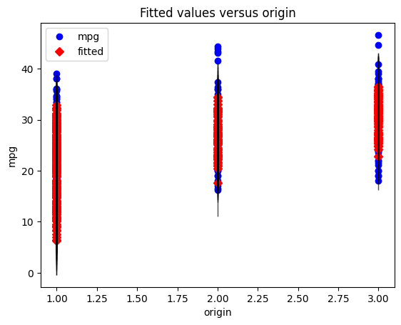

```python
# BEGIN SOLUTION
plot_fit(multi_lin_reg,exog_idx=X.columns.get_loc('displacement'))
plt.show()

plot_fit(multi_lin_reg,exog_idx=X.columns.get_loc('weight'))
plt.show()

plot_fit(multi_lin_reg,exog_idx=X.columns.get_loc('year'))
plt.show()

plot_fit(multi_lin_reg,exog_idx=X.columns.get_loc('origin'))
plt.show()
# END SOLUTION
```

### using plot_leverage_resid2

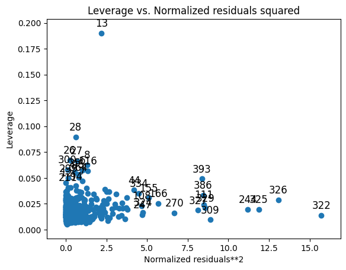

```python
# BEGIN SOLUTION

from statsmodels.graphics.regressionplots import plot_leverage_resid2

plot_leverage_resid2(multi_lin_reg)
plt.show()
# END SOLUTION
```

Provide your comments in this Markdown cell

1. In the graphs obtained from the plot_fit() function, the spread of the residuals varies for every predictor. This indicates heteroscedasticity and violates the constant variance of error $\epsilon$ assumption.
2. From the leverage vs normalized residuals graph we can notice that there are points with high leverage value and low normalized residuals. These points are leverage points. Point 13 is a leverage point.
3. Also the point numbered 13 seem to have extreme predictor values because it has a high leverage value.

### e) Fit a linear regression model with interaction effects. explore a few different models (~3–4 models). Do any interactions appear to be statistically significant in any of the models you examined?

Use formula.ols to check the interaction between two predictors as used in the below reference link

https://www.statsmodels.org/devel/example_formulas.html

```python
# BEGIN SOLUTION
import statsmodels.formula.api as smf

new_df = auto_df[['mpg','displacement','weight','year','origin']] # these columns or predictors are choosen because they have significant relationship to the response mpg

model_expresion1 = 'mpg ~ displacement*weight'
interaction_model1 = smf.ols(formula=model_expresion1,data=new_df).fit()
print('Interaction between displacement & weight\n\n',interaction_model1.summary(),'\n\n\n\n')

model_expresion2 = 'mpg ~ year*origin'
interaction_model2 = smf.ols(formula=model_expresion2,data=new_df).fit()
print('Interaction between year & origin\n\n',interaction_model2.summary(),'\n\n\n\n')

model_expresion3 = 'mpg ~ displacement*origin'
interaction_model3 = smf.ols(formula=model_expresion3,data=new_df).fit()
print('Interaction between displacement & origin\n\n',interaction_model3.summary(),'\n\n\n\n')

model_expresion4 = 'mpg ~ year*weight'
interaction_model4 = smf.ols(formula=model_expresion4,data=new_df).fit()
print('Interaction between year & weight\n\n',interaction_model4.summary())
# END SOLUTION
```

```
Interaction between displacement & weight

                             OLS Regression Results
==============================================================================
Dep. Variable:                    mpg   R-squared:                       0.727
Model:                            OLS   Adj. R-squared:                  0.724
Method:                 Least Squares   F-statistic:                     343.6
Date:                Wed, 03 Apr 2024   Prob (F-statistic):          7.76e-109
Time:                        03:43:46   Log-Likelihood:                -1107.1
No. Observations:                 392   AIC:                             2222.
Df Residuals:                     388   BIC:                             2238.
Df Model:                           3
Covariance Type:            nonrobust
=======================================================================================
                          coef    std err          t      P>|t|      [0.025      0.975]
---------------------------------------------------------------------------------------
Intercept              53.7244      1.940     27.697      0.000      49.911      57.538
displacement           -0.0783      0.011     -6.922      0.000      -0.101      -0.056
weight                 -0.0089      0.001    -10.539      0.000      -0.011      -0.007
displacement:weight  1.744e-05   2.79e-06      6.253      0.000     1.2e-05    2.29e-05
==============================================================================
Omnibus:                       56.117   Durbin-Watson:                   0.805
Prob(Omnibus):                  0.000   Jarque-Bera (JB):              113.229
Skew:                           0.783   Prob(JB):                     2.59e-25
Kurtosis:                       5.117   Cond. No.                     7.90e+06
==============================================================================

Notes:
[1] Standard Errors assume that the covariance matrix of the errors is correctly specified.
[2] The condition number is large, 7.9e+06. This might indicate that there are
strong multicollinearity or other numerical problems.




Interaction between year & origin

                             OLS Regression Results
==============================================================================
Dep. Variable:                    mpg   R-squared:                       0.560
```

[output cut: 81 more lines]

```
Intercept    -110.4519     12.947     -8.531      0.000    -135.907     -84.997
year            2.0405      0.172     11.876      0.000       1.703       2.378
weight          0.0275      0.004      6.242      0.000       0.019       0.036
year:weight    -0.0005   5.91e-05     -7.752      0.000      -0.001      -0.000
==============================================================================
Omnibus:                       48.151   Durbin-Watson:                   1.345
Prob(Omnibus):                  0.000   Jarque-Bera (JB):               86.841
Skew:                           0.722   Prob(JB):                     1.39e-19
Kurtosis:                       4.798   Cond. No.                     1.87e+07
==============================================================================

Notes:
[1] Standard Errors assume that the covariance matrix of the errors is correctly specified.
[2] The condition number is large, 1.87e+07. This might indicate that there are
strong multicollinearity or other numerical problems.
```

1. Out of the 4 models with interaction effects examined in the above cell, 3 of the interactions have a significant relationship to the response mpg.
2. The interactions displacement:weight, displacement:origin and year:weight have a significant relationship with the response mpg.
3. The interaction year:origin does not have any significant relationship with the response mpg.

### f) Try a few different transformations of the variables, such as `log(X)`, `sqrt(X)`, $X^2$. Comment on your findings.

```python
# BEGIN SOLUTION
Y = auto_df['mpg']
X = (auto_df.drop(['mpg','name'], axis=1))

X_log = sm.add_constant(np.log(X+1))
log_model = sm.OLS(Y,X_log).fit()
print("Summary for log model\n\n",log_model.summary(),'\n\n\n\n')


X_sqrt = sm.add_constant(np.sqrt(X))
sqrt_model = sm.OLS(Y,X_sqrt).fit()
print("Summary for sqrt model\n\n",sqrt_model.summary(),'\n\n\n\n')

X_square = sm.add_constant(X**2)
square_model = sm.OLS(Y,X_square).fit()
print("Summary for squared model\n\n",square_model.summary())
# END SOLUTION
```

```
Summary for log model

                             OLS Regression Results
==============================================================================
Dep. Variable:                    mpg   R-squared:                       0.848
Model:                            OLS   Adj. R-squared:                  0.845
Method:                 Least Squares   F-statistic:                     305.6
Date:                Wed, 03 Apr 2024   Prob (F-statistic):          1.06e-152
Time:                        03:45:19   Log-Likelihood:                -992.17
No. Observations:                 392   AIC:                             2000.
Df Residuals:                     384   BIC:                             2032.
Df Model:                           7
Covariance Type:            nonrobust
================================================================================
                   coef    std err          t      P>|t|      [0.025      0.975]
--------------------------------------------------------------------------------
const          -70.8276     17.846     -3.969      0.000    -105.916     -35.740
cylinders        1.8449      1.967      0.938      0.349      -2.023       5.713
displacement    -1.1250      1.529     -0.736      0.462      -4.131       1.881
horsepower      -6.9435      1.579     -4.398      0.000     -10.048      -3.839
weight         -12.6429      2.223     -5.687      0.000     -17.014      -8.272
acceleration    -5.1752      1.719     -3.011      0.003      -8.554      -1.796
year            55.5982      3.608     15.408      0.000      48.504      62.693
origin           2.4882      0.809      3.077      0.002       0.898       4.078
==============================================================================
Omnibus:                       41.702   Durbin-Watson:                   1.393
Prob(Omnibus):                  0.000   Jarque-Bera (JB):               83.834
Skew:                           0.598   Prob(JB):                     6.25e-19
Kurtosis:                       4.924   Cond. No.                     1.40e+03
==============================================================================

Notes:
[1] Standard Errors assume that the covariance matrix of the errors is correctly specified.
[2] The condition number is large, 1.4e+03. This might indicate that there are
strong multicollinearity or other numerical problems.




Summary for sqrt model
```

[output cut: 58 more lines]

```
weight       -9.351e-07   8.98e-08    -10.416      0.000   -1.11e-06   -7.59e-07
acceleration     0.0063      0.003      2.334      0.020       0.001       0.012
year             0.0050      0.000     14.160      0.000       0.004       0.006
origin           0.4129      0.069      5.971      0.000       0.277       0.549
==============================================================================
Omnibus:                       21.204   Durbin-Watson:                   1.316
Prob(Omnibus):                  0.000   Jarque-Bera (JB):               29.337
Skew:                           0.431   Prob(JB):                     4.26e-07
Kurtosis:                       4.027   Cond. No.                     1.45e+08
==============================================================================

Notes:
[1] Standard Errors assume that the covariance matrix of the errors is correctly specified.
[2] The condition number is large, 1.45e+08. This might indicate that there are
strong multicollinearity or other numerical problems.
```

1. Different transformations of variables result in different predictors showing significant relationship with the response mpg.
2. The $\log{X}$ transformation of variables indicate that the predictors horsepower, weight, acceleration, year and origin have a significant relationship with the response mpg.
3. The $\sqrt{X}$ transformation of variables indicate that the predictors horsepower, weight, year and origin have a significant relationship with the response mpg.
4. The $X^2$ transformation of the variables indicate that the predictors cylinders, displacement, weight, acceleration, year and origin have a significant relationship with the response mpg.

## Question 6

In this exercise you will create some simulated data and will fit simple linear regression models to it. Make sure to use `set.seed(1)` prior to starting part (a) to ensure consistent results.

### a) Using the random normal function, create a vector, `x`, containing 100 observations drawn from a $N(0, 1)$ distribution. This represents a feature, `X`.

Link to random normal function: https://numpy.org/doc/stable/reference/random/generated/numpy.random.normal.html

```python
# BEGIN SOLUTION
np.random.seed(1)
x = np.random.normal(loc=0, scale=1, size=100)
print(x)
# END SOLUTION
```

```
[ 1.62434536 -0.61175641 -0.52817175 -1.07296862  0.86540763 -2.3015387
  1.74481176 -0.7612069   0.3190391  -0.24937038  1.46210794 -2.06014071
 -0.3224172  -0.38405435  1.13376944 -1.09989127 -0.17242821 -0.87785842
  0.04221375  0.58281521 -1.10061918  1.14472371  0.90159072  0.50249434
  0.90085595 -0.68372786 -0.12289023 -0.93576943 -0.26788808  0.53035547
 -0.69166075 -0.39675353 -0.6871727  -0.84520564 -0.67124613 -0.0126646
 -1.11731035  0.2344157   1.65980218  0.74204416 -0.19183555 -0.88762896
 -0.74715829  1.6924546   0.05080775 -0.63699565  0.19091548  2.10025514
  0.12015895  0.61720311  0.30017032 -0.35224985 -1.1425182  -0.34934272
 -0.20889423  0.58662319  0.83898341  0.93110208  0.28558733  0.88514116
 -0.75439794  1.25286816  0.51292982 -0.29809284  0.48851815 -0.07557171
  1.13162939  1.51981682  2.18557541 -1.39649634 -1.44411381 -0.50446586
  0.16003707  0.87616892  0.31563495 -2.02220122 -0.30620401  0.82797464
  0.23009474  0.76201118 -0.22232814 -0.20075807  0.18656139  0.41005165
  0.19829972  0.11900865 -0.67066229  0.37756379  0.12182127  1.12948391
  1.19891788  0.18515642 -0.37528495 -0.63873041  0.42349435  0.07734007
 -0.34385368  0.04359686 -0.62000084  0.69803203]
```

### b) Using the `random normal` function, create a vector, `eps`, containing 100 observations drawn from a $N(0, 0.25)$ distribution — a normal distribution with mean zero and variance `0.25`.

Link to random normal function: https://numpy.org/doc/stable/reference/random/generated/numpy.random.normal.html

```python
# BEGIN SOLUTION
eps = np.random.normal(loc=0, scale=0.5, size=100) # scale = standard deviation = sqrt(variance)
print(eps)
# END SOLUTION
```

```
[-0.22356428  0.61225385  0.20174582  0.29678926 -0.54745592  0.08469122
  0.37027823 -0.4768503  -0.13310925  0.01630727 -0.68655866  0.1575797
  0.42308032 -0.42975797  0.17527299 -0.65614171 -0.01934775 -0.80788618
  0.56070885  0.20445027 -0.01230848 -0.38758081  0.63687797  0.98355087
 -0.92899093  0.61808202  0.81382538  0.16900585 -0.59963402  0.43167266
 -0.09046015 -0.30196031 -0.61502907  0.27526875  0.39640343 -0.31176536
  0.26028817 -0.57217069  0.40093052  0.02328365 -0.09328489 -0.05087294
  0.43444308  0.37520582  0.26473266  0.0688506   0.03891056  0.30919013
  0.11624728  0.3412757  -0.15505839 -1.21741888  0.5194123   1.09348982
  0.22068222 -0.05007762 -0.06822237 -0.05952709  0.0087047  -0.56100936
 -0.25854723 -0.49851341  0.12439958 -0.14832058  0.24760566 -0.08735158
  0.49316759  0.10676695  1.09534986 -0.94818046 -0.32345834  0.45074345
  1.26416285 -0.12431739  0.0218345  -0.11315712  0.66572856 -0.14365393
  0.34003492 -0.1599008  -0.63627938  0.15677386  0.25159241  0.64661294
 -0.05522351 -0.30868103  0.28138055  0.12036855  0.14033254 -0.03655635
  0.58016928  0.18474636  0.95232935  0.55552835  0.3295249  -0.81371917
  0.30115964  0.2101411   0.40547584  0.52222105]
```

### c) Using `x` and `eps`, generate a vector `y` according to the model $Y = -1 + 0.5X + ϵ$. What is the length of the vector `y`? What are the values of $β_0$ and $β_1$ in this linear model?

```python
# BEGIN SOLUTION
y = -1 + 0.5*x + eps
print("Length of vector y is",len(y))
# END SOLUTION
```

```
Length of vector y is 100
```

Provide you comments / answer here

- The value of $\beta_{0}$ is -1 and the value of $\beta_{1}$ is 0.5. The length of vector y is 100.

### d) Create a scatterplot displaying the relationship between `x` and `y`. Comment on what you observe.

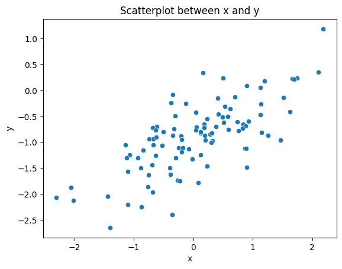

```python
# BEGIN SOLUTION

sns.scatterplot(x=x, y=y)
plt.xlabel("x")
plt.ylabel("y")
plt.title("Scatterplot between x and y")
plt.show()
# END SOLUTION
```

Provide you comments / answer here

The points are scattered but they appear to be linear.

### e) Fit a least squares linear model that relates y and `x`. Comment on the model obtained. How do the estimated coefficients (slope and intercept) compare to the true values used to simulate the data?

```python
# BEGIN SOLUTION
new_x = sm.add_constant(x)
ls_lin_model = sm.OLS(y,new_x).fit()

est_intercept = (ls_lin_model.params[0])
est_slope = (ls_lin_model.params[1])
print(ls_lin_model.summary(),'\n\n\n')
print(f'Estimated intercept = {est_intercept} and Estimated slope = {est_slope}')
# END SOLUTION
```

```
                            OLS Regression Results
==============================================================================
Dep. Variable:                      y   R-squared:                       0.522
Model:                            OLS   Adj. R-squared:                  0.517
Method:                 Least Squares   F-statistic:                     107.0
Date:                Wed, 03 Apr 2024   Prob (F-statistic):           2.20e-17
Time:                        04:11:24   Log-Likelihood:                -65.124
No. Observations:                 100   AIC:                             134.2
Df Residuals:                      98   BIC:                             139.5
Df Model:                           1
Covariance Type:            nonrobust
==============================================================================
                 coef    std err          t      P>|t|      [0.025      0.975]
------------------------------------------------------------------------------
const         -0.9265      0.047    -19.717      0.000      -1.020      -0.833
x1             0.5477      0.053     10.342      0.000       0.443       0.653
==============================================================================
Omnibus:                        0.898   Durbin-Watson:                   2.157
Prob(Omnibus):                  0.638   Jarque-Bera (JB):                0.561
Skew:                          -0.172   Prob(JB):                        0.755
Kurtosis:                       3.127   Cond. No.                         1.15
==============================================================================

Notes:
[1] Standard Errors assume that the covariance matrix of the errors is correctly specified.



Estimated intercept = -0.9264932351508993 and Estimated slope = 0.5477135668255861
```

Provide you comments / answer here

1. The parameter estimates are close to the true values but not exactly same.
2. The estimate of intercept is -0.9265 whereas the true intercept is -1. Both are similar to each other.
3. The estimate of slope is 0.5477 whereas the true slope is 0.5. Both estimate and true value are similar to each other.

### f) Display the least squares line on the scatterplot obtained in (d). Draw the estimated regression line on the plot, in a different color. Feel free to use any framework such as ggplot or matplotlib, seaborn etc

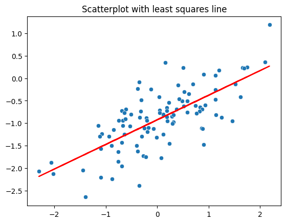

```python
# BEGIN SOLUTION
sns.scatterplot(x=x, y=y)
plt.plot(x,est_intercept + est_slope*x, color='red')
plt.title('Scatterplot with least squares line')
plt.show()
# END SOLUTION
```

Provide you comments / answer here

The regression line in red color fits the data points well.

### g) Now fit a polynomial regression model that predicts $y$ using $x$ and $x^2$. Is there evidence that the quadratic term improves the model fit? Explain your answer.

```python
# BEGIN SOLUTION
quadratic_x = sm.add_constant(np.column_stack((x,x**2)))
quadratic_model = sm.OLS(y,quadratic_x).fit()
print(quadratic_model.summary())

# END SOLUTION
```

```
                            OLS Regression Results
==============================================================================
Dep. Variable:                      y   R-squared:                       0.522
Model:                            OLS   Adj. R-squared:                  0.512
Method:                 Least Squares   F-statistic:                     52.96
Date:                Wed, 03 Apr 2024   Prob (F-statistic):           2.83e-16
Time:                        05:55:20   Log-Likelihood:                -65.107
No. Observations:                 100   AIC:                             136.2
Df Residuals:                      97   BIC:                             144.0
Df Model:                           2
Covariance Type:            nonrobust
==============================================================================
                 coef    std err          t      P>|t|      [0.025      0.975]
------------------------------------------------------------------------------
const         -0.9325      0.058    -16.158      0.000      -1.047      -0.818
x1             0.5468      0.053     10.229      0.000       0.441       0.653
x2             0.0077      0.043      0.181      0.856      -0.077       0.092
==============================================================================
Omnibus:                        0.893   Durbin-Watson:                   2.152
Prob(Omnibus):                  0.640   Jarque-Bera (JB):                0.552
Skew:                          -0.170   Prob(JB):                        0.759
Kurtosis:                       3.132   Cond. No.                         2.10
==============================================================================

Notes:
[1] Standard Errors assume that the covariance matrix of the errors is correctly specified.
```

Provide you comments / answer here

There is no evidence that the quadratic term improves the model fit. $R^2$ for both the linear regression and polynomial models is 0.522. Moreover, the p-value of the $x^{2}$ term is 0.856 indicating that the null hypothesis is true and there is no significant relationship between $y$ and $x^{2}$. Thus, the quadratic term doesn't improve the model fit.

### h) Repeat (a)–(f) after modifying the data generation process in such a way that there is less noise in the data. The model analyzed in this section,, should remain the same. You can do this by decreasing the variance of the normal distribution used to generate the error term ϵ in (b). Describe your results.

```
Length of vector y is 100
```

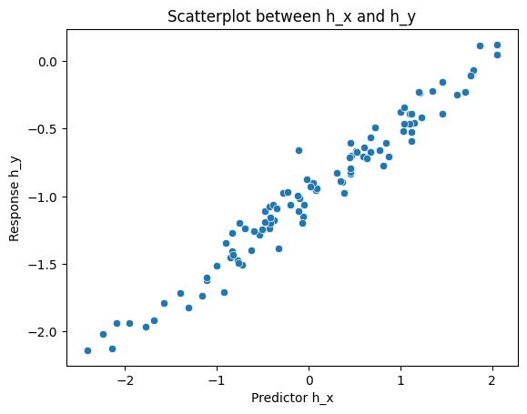

```
                            OLS Regression Results
==============================================================================
Dep. Variable:                      y   R-squared:                       0.963
Model:                            OLS   Adj. R-squared:                  0.962
Method:                 Least Squares   F-statistic:                     2525.
Date:                Wed, 03 Apr 2024   Prob (F-statistic):           9.12e-72
Time:                        06:15:44   Log-Likelihood:                 84.594
No. Observations:                 100   AIC:                            -165.2
Df Residuals:                      98   BIC:                            -160.0
Df Model:                           1
Covariance Type:            nonrobust
==============================================================================
                 coef    std err          t      P>|t|      [0.025      0.975]
------------------------------------------------------------------------------
const         -0.9880      0.011    -94.008      0.000      -1.009      -0.967
x1             0.5090      0.010     50.252      0.000       0.489       0.529
==============================================================================
Omnibus:                        3.633   Durbin-Watson:                   1.972
Prob(Omnibus):                  0.163   Jarque-Bera (JB):                3.566
Skew:                           0.192   Prob(JB):                        0.168
Kurtosis:                       3.842   Cond. No.                         1.07
==============================================================================

Notes:
[1] Standard Errors assume that the covariance matrix of the errors is correctly specified.



Estimated intercept = -0.9880220643642997 and Estimated slope = 0.509029913714787
```

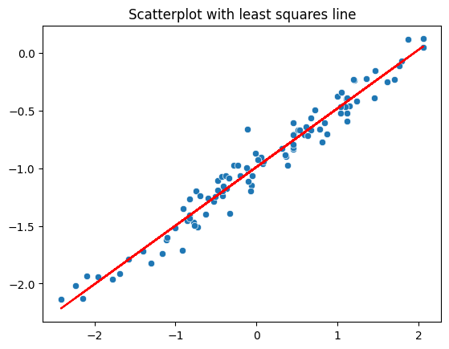

```python
# BEGIN SOLUTION

# part-(a)

h_x = np.random.normal(loc=0, scale=1, size=100)

# part-(b)

h_eps = np.random.normal(loc=0, scale=0.1, size=100)

# part-(c)
h_y = -1 + 0.5*h_x + h_eps
print("Length of vector y is",len(h_y))

# part-(d)
sns.scatterplot(x=h_x, y=h_y)
plt.xlabel("Predictor h_x")
plt.ylabel("Response h_y")
plt.title("Scatterplot between h_x and h_y")
plt.show()

# part-(e)
new_hx = sm.add_constant(h_x)
ls_lin_model_h = sm.OLS(h_y,new_hx).fit()
est_intercept_h = (ls_lin_model_h.params[0])
est_slope_h = (ls_lin_model_h.params[1])
print(ls_lin_model_h.summary(),'\n\n\n')
print(f'Estimated intercept = {est_intercept_h} and Estimated slope = {est_slope_h}')

# part-(f)
sns.scatterplot(x=h_x, y=h_y)
plt.plot(h_x, est_intercept_h + est_slope_h*h_x, color='red')
plt.title('Scatterplot with least squares line')
plt.show()
# END SOLUTION
```

Provide you comments / answer here

1. In this case, the standard deviation($\sigma$) of error($\epsilon$) is 0.1 that is variance($\sigma^{2}$) of the error is 0.01
2. Here the $R^{2}$ value is 0.963 is higher than that of the original model.
3. Moreover, the estimate of intercept -0.9880 and the estimate of slope 0.5090 are more closer to the true values of intercept(-1) and slope(0.5). Hence, it is a better fit than the original model whose noise variance is 0.25.

### i) Repeat (a)–(f) after modifying the data generation process in such a way that there is more noise in the data. The model analyzed in this section ($Y = -1 + 0.5X + ϵ$) should remain the same. You can do this by increasing the variance of the normal distribution used to generate the error term $ϵ$ in (b). Describe your results.

```
Length of vector y is 100
```

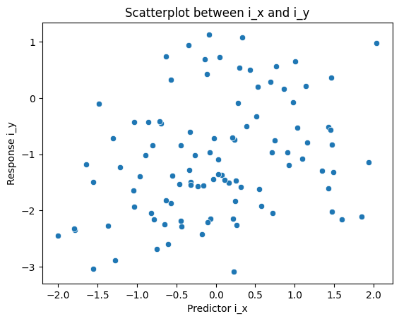

```
                            OLS Regression Results
==============================================================================
Dep. Variable:                      y   R-squared:                       0.087
Model:                            OLS   Adj. R-squared:                  0.078
Method:                 Least Squares   F-statistic:                     9.382
Date:                Wed, 03 Apr 2024   Prob (F-statistic):            0.00283
Time:                        06:34:44   Log-Likelihood:                -139.87
No. Observations:                 100   AIC:                             283.7
Df Residuals:                      98   BIC:                             288.9
Df Model:                           1
Covariance Type:            nonrobust
==============================================================================
                 coef    std err          t      P>|t|      [0.025      0.975]
------------------------------------------------------------------------------
const         -1.0830      0.099    -10.939      0.000      -1.279      -0.887
x1             0.3289      0.107      3.063      0.003       0.116       0.542
==============================================================================
Omnibus:                        4.567   Durbin-Watson:                   1.766
Prob(Omnibus):                  0.102   Jarque-Bera (JB):                3.788
Skew:                           0.373   Prob(JB):                        0.150
Kurtosis:                       2.407   Cond. No.                         1.09
==============================================================================

Notes:
[1] Standard Errors assume that the covariance matrix of the errors is correctly specified.



Estimated intercept = -1.082972900403278 and Estimated slope = 0.3288620954214573
```

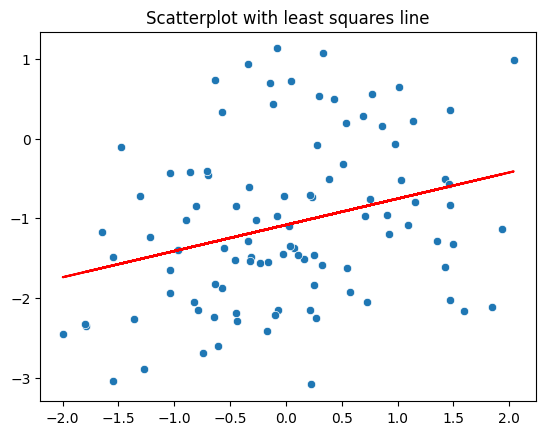

```python
# BEGIN SOLUTION
# part-(a)

i_x = np.random.normal(loc=0, scale=1, size=100)

# part-(b)

i_eps = np.random.normal(loc=0, scale=1, size=100)

# part-(c)
i_y = -1 + 0.5*i_x + i_eps
print("Length of vector y is",len(i_y))

# part-(d)
sns.scatterplot(x=i_x, y=i_y)
plt.xlabel("Predictor i_x")
plt.ylabel("Response i_y")
plt.title("Scatterplot between i_x and i_y")
plt.show()

# part-(e)
new_ix = sm.add_constant(i_x)
ls_lin_model_i = sm.OLS(i_y,new_ix).fit()
est_intercept_i = (ls_lin_model_i.params[0])
est_slope_i = (ls_lin_model_i.params[1])
print(ls_lin_model_i.summary(),'\n\n\n')
print(f'Estimated intercept = {est_intercept_i} and Estimated slope = {est_slope_i}')

# part-(f)
sns.scatterplot(x=i_x, y=i_y)
plt.plot(i_x, est_intercept_i + est_slope_i*i_x, color='red')
plt.title('Scatterplot with least squares line')
plt.show()

# END SOLUTION
```

Provide you comments / answer here

1. In the model with more noise whose $var(\sigma^{2}) = 1$ or $\sigma = 1$, the estimated intercept -1.0830 and the estimated slope 0.3289 are farther away from the true intercept(-1) and the true slope(0.5).
2. Moreover, the $R^{2}$ value 0.087 is smaller than that of the original model.
3. This is a worse fit than the original one.

### j) What are the confidence intervals for $β_0$ and $β_1$ based on the original data set, the noisier data set, and the less noisy data set? Comment on your results.

```python
# BEGIN SOLUTION
org_conf_int = ls_lin_model.conf_int(alpha=0.05)

beta0_org_cint = [org_conf_int[0,0], org_conf_int[0,1]]
beta1_org_cint = [org_conf_int[1,0], org_conf_int[1,1]]

print(f"Confidence interval for intercept on the original dataset is {beta0_org_cint}")
print(f"Confidence interval for slope on the original dataset is {beta1_org_cint}\n")

less_noise_conf_int = ls_lin_model_h.conf_int(alpha=0.05)
beta0_less_noise_cint = [less_noise_conf_int[0,0], less_noise_conf_int[0,1]]
beta1_less_noise_cint = [less_noise_conf_int[1,0], less_noise_conf_int[1,1]]

print(f"Confidence interval for intercept on the less noisy dataset is {beta0_less_noise_cint}")
print(f"Confidence interval for slope on the less noisy dataset is {beta1_less_noise_cint}\n")

more_noise_conf_int = ls_lin_model_i.conf_int(alpha=0.05)
beta0_more_noise_cint = [more_noise_conf_int[0,0],more_noise_conf_int[0,1]]
beta1_more_noise_cint = [more_noise_conf_int[1,0], more_noise_conf_int[1,1]]

print(f"Confidence interval for intercept on the more noisy dataset is {beta0_more_noise_cint}")
print(f"Confidence interval for slope on the more noisy dataset is {beta1_more_noise_cint}\n")
# END SOLUTION
```

```
Confidence interval for intercept on the original dataset is [-1.0197409646810807, -0.833245505620718]
Confidence interval for slope on the original dataset is [0.44261337684768454, 0.6528137568034877]

Confidence interval for intercept on the less noisy dataset is [-1.0088786914848926, -0.9671654372437067]
Confidence interval for slope on the less noisy dataset is [0.48892819888203404, 0.5291316285475399]

Confidence interval for intercept on the more noisy dataset is [-1.2794397013852987, -0.8865060994212572]
Confidence interval for slope on the more noisy dataset is [0.11579345609347752, 0.5419307347494371]
```

Provide you comments / answer here

It is clear from the above observations that the width of the confidence interval increases as the noise increases.

## Question 7

This question focuses on the collinearity problem

## (a) Perform the following commands in `Python`

```python
import numpy as np

np.random.seed(1)

x1 = np.random.uniform(size=100)

x2 = 0.5 * x1 + np.random.normal(size=100) / 10

y = 2 + 2 * x1 + 0.3 * x2 + np.random.normal(size=100)
```

The last line corresponds to creating a linear model in which $y$ is a function of $x_1$ and $x_2$. Write out the form of the linear model. What are the regression coefficients?

Provide you comments / answer here

1. The linear model is given by $Y = 2 + 2X_{1} + 0.3X_{2} + \epsilon$
2. Regression coefficients are
   - $intercept = \beta_{0} = 2 $
   - $\beta_{1} = 2$
   - $\beta_{2} = 0.3$

## (b) What is the correlation between $x_1$ and $x_2$? Create a scatterplot displaying the relationship between the variables.

link to correlation function: https://numpy.org/doc/stable/reference/generated/numpy.corrcoef.html

```
Correlation between x1 and x2 is 0.8390596222844917
```

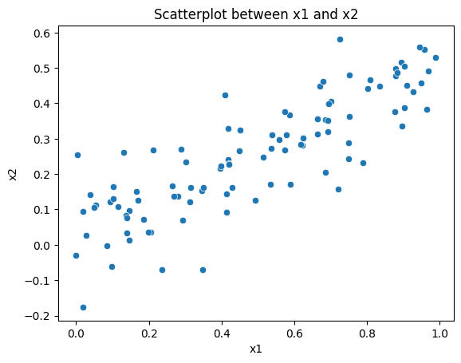

```python
# BEGIN SOLUTION
corr = np.corrcoef(x1,x2)
print(f'Correlation between x1 and x2 is {corr[0,1]}')

sns.scatterplot(x=x1, y=x2)
plt.xlabel('x1')
plt.ylabel('x2')
plt.title('Scatterplot between x1 and x2')
plt.show()
# END SOLUTION
```

## (c) Using this data, fit a least squares regression to predict $y$ using $x_1$ and $x_2$. Describe the results obtained. What are $β_0$, $β_1$, and $β_2$? How do these relate to the true $β_0$, $β_1$, and $β_2$? Can you reject the null hypothesis $H_0$: $β_1$ = 0? How about the null hypothesis $H_0$: $β_2$ = 0?

```python
# BEGIN SOLUTION
 # we are representing it in a dataframe format because it led to inconsistent variable names while doing OLS fit.
X = pd.DataFrame({'x1':x1, 'x2':x2})
X = sm.add_constant(X)

lst_sq_model = sm.OLS(y,X).fit()

print(lst_sq_model.summary())

# END SOLUTION
```

```
                            OLS Regression Results
==============================================================================
Dep. Variable:                      y   R-squared:                       0.261
Model:                            OLS   Adj. R-squared:                  0.245
Method:                 Least Squares   F-statistic:                     17.09
Date:                Wed, 03 Apr 2024   Prob (F-statistic):           4.40e-07
Time:                        07:16:11   Log-Likelihood:                -142.34
No. Observations:                 100   AIC:                             290.7
Df Residuals:                      97   BIC:                             298.5
Df Model:                           2
Covariance Type:            nonrobust
==============================================================================
                 coef    std err          t      P>|t|      [0.025      0.975]
------------------------------------------------------------------------------
const          2.1893      0.199     11.021      0.000       1.795       2.584
x1             0.7046      0.637      1.107      0.271      -0.559       1.968
x2             2.5024      1.140      2.194      0.031       0.239       4.766
==============================================================================
Omnibus:                        0.607   Durbin-Watson:                   2.111
Prob(Omnibus):                  0.738   Jarque-Bera (JB):                0.577
Skew:                          -0.179   Prob(JB):                        0.749
Kurtosis:                       2.900   Cond. No.                         14.3
==============================================================================

Notes:
[1] Standard Errors assume that the covariance matrix of the errors is correctly specified.
```

Provide you comments / answer here

1. The estimated values of the regression coefficients are
   - $\hat{\beta_{0}} = 2.1893$
   - $\hat{\beta_{1}} = 0.7046$
   - $\hat{\beta_{2}} = 2.5024$
2. The estimated value $\hat{\beta_{0}}=2.1893$ is close to the true value $\beta_{0}=2$.
3. The estimated value $\hat{\beta_{1}} = 0.7046$ is quite different from the true value $\beta_{1}=2$.
4. The estimated value $\hat{\beta_{2}} = 2.5024$ is also quite different from the true value $\beta_{2}=0.3$.
5. The p-value for the parameter estimate of x1 is 0.271 which is greater than the threshold 0.05. Hence, null hypothesis holds true and there is no significant relationship between the predictor x1 and the response y in the presence of x2 and intercept.
6. The p-value for the parameter estimate of x2 is 0.031 which is smaller than the threshold 0.05. Hence, null hypothesis is not true and there is a significant relationship between the predictor x2 and the response y in the presence of x1 and intercept.

## (d) Now fit a least squares regression to predict $y$ using only $x_1$. Comment on your results. Can you reject the null hypothesis $H_0$: $β_1$ = 0?

```python
# BEGIN SOLUTION

X1 = sm.add_constant(pd.DataFrame({'x1':x1}))
model_x1 = sm.OLS(y,X1).fit()

print(model_x1.summary())

# END SOLUTION
```

```
                            OLS Regression Results
==============================================================================
Dep. Variable:                      y   R-squared:                       0.224
Model:                            OLS   Adj. R-squared:                  0.216
Method:                 Least Squares   F-statistic:                     28.26
Date:                Wed, 03 Apr 2024   Prob (F-statistic):           6.68e-07
Time:                        07:37:46   Log-Likelihood:                -144.76
No. Observations:                 100   AIC:                             293.5
Df Residuals:                      98   BIC:                             298.7
Df Model:                           1
Covariance Type:            nonrobust
==============================================================================
                 coef    std err          t      P>|t|      [0.025      0.975]
------------------------------------------------------------------------------
const          2.2486      0.201     11.209      0.000       1.850       2.647
x1             1.8770      0.353      5.316      0.000       1.176       2.578
==============================================================================
Omnibus:                        0.292   Durbin-Watson:                   2.123
Prob(Omnibus):                  0.864   Jarque-Bera (JB):                0.468
Skew:                          -0.003   Prob(JB):                        0.791
Kurtosis:                       2.665   Cond. No.                         4.26
==============================================================================

Notes:
[1] Standard Errors assume that the covariance matrix of the errors is correctly specified.
```

Provide you comments / answer here

1. Here, the parameter estimate of $x_{1}$ 1.8770 is greater than that of the model with both x1 and x2.
2. The p-value for the parameter estimate of x1 is 0.000 which is smaller than the threshold 0.05. Hence, null hypothesis is rejected and there exists a significant relationship between the predictor x1 and the response y.

## (e) Now fit a least squares regression to predict $y$ using only $x_2$. Comment on your results. Can you reject the null hypothesis $H_0$: $β_2$ = 0?

```python
# BEGIN SOLUTION
X2 = sm.add_constant(pd.DataFrame({'x2':x2}))
model_x2 = sm.OLS(y,X2).fit()

print(model_x2.summary())
# END SOLUTION
```

```
                            OLS Regression Results
==============================================================================
Dep. Variable:                      y   R-squared:                       0.251
Model:                            OLS   Adj. R-squared:                  0.244
Method:                 Least Squares   F-statistic:                     32.87
Date:                Wed, 03 Apr 2024   Prob (F-statistic):           1.09e-07
Time:                        07:33:44   Log-Likelihood:                -142.97
No. Observations:                 100   AIC:                             289.9
Df Residuals:                      98   BIC:                             295.1
Df Model:                           1
Covariance Type:            nonrobust
==============================================================================
                 coef    std err          t      P>|t|      [0.025      0.975]
------------------------------------------------------------------------------
const          2.2655      0.187     12.145      0.000       1.895       2.636
x2             3.5613      0.621      5.733      0.000       2.329       4.794
==============================================================================
Omnibus:                        0.857   Durbin-Watson:                   2.117
Prob(Omnibus):                  0.651   Jarque-Bera (JB):                0.746
Skew:                          -0.210   Prob(JB):                        0.689
Kurtosis:                       2.946   Cond. No.                         6.48
==============================================================================

Notes:
[1] Standard Errors assume that the covariance matrix of the errors is correctly specified.
```

Provide you comments / answer here

1. Here, the parameter estimate of $x_{2}$ 3.5613 is greater than that of the model with both x1 and x2.
2. The p-value for the parameter estimate of x2 is 0.000 which is smaller than the threshold 0.05. Hence, null hypothesis is rejected and there exists a significant relationship between the predictor x2 and the response y.

## (f) Do the results obtained in (c)–(e) contradict each other? Explain your answer.

Provide you comments / answer here

1. The parameter estimate of predictor x1 in the model(c) $\hat\beta_{1c}=0.7046$ is different from the parameter estimate of predictor x1 in the model(d) $\hat\beta_{1d}=1.8770$. This indicates that there is an effect on x1 when x2 is included in the model.
2. The parameter estimate of predictor x2 in the model(c) $\hat\beta_{2c}=2.5024$ is different from the parameter estimate of predictor x2 in the model(e) $\hat\beta_{2e}=3.5613$.
3. Model (d) has a p-value of 0.000 for the parameter estimate of x1 which is less than the threshold 0.05. This indicates that there is a significant relationship between the predictor x1 and the response y.
4. Model (e) has a p-value of 0.000 for the parameter estimate of x2 which is less than the threshold 0.05. This indicates that there is a significant relationship between the predictor x2 and the response y.
5. In model (c) the p-value for the parameter estimate of x1 is 0.271 which is greater than the threshold 0.05. This indicates that there is no relationship between x1 and y.
6. In model (c) the p-value for the parameter estimate of x2 is 0.031 which is less than the threshold 0.05. This indicates that there is a significant relationship between x2 and y.
7. The correlation between x1 and x2 is 0.839. It is indicated by the scatterplot that x1 can be predicted from x2 using a linear model and vice-versa is also true.
8. When x1 and x2 are used separately to predict y, both show a significant relationship with response y as shown in model (d),(e) but when both x1 and x2 are included together x1 looses significance because its variability is explained by x2 as shown in model (c). This is because of the collinearity present between the two predictors x1 and x2.
9. Thus, the results are not contradicting but they are supporting the presence of collinearity between x1 and x2.

## (g) Now suppose we obtain one additional observation, which was unfortunately mismeasured. Re-fit the linear models from (c) to (e) using this new data. What effect does this new observation have on each of the models? In each model, is this observation an outlier? A high-leverage point? Both? Explain your answers.

```python
# BEGIN SOLUTION
df = pd.DataFrame({'x1':x1,'x2':x2,'y':y})

x1_new = 0.1
x2_new = 2.5
y_new = 7

new_obs_df = pd.DataFrame({'x1': [x1_new], 'x2': [x2_new], 'y': [y_new]})

updated_df = pd.concat([df,new_obs_df], ignore_index=True)

combined_model = sm.OLS(updated_df['y'],sm.add_constant(updated_df[['x1','x2']])).fit()
print("Model summary when both x1 and x2 are included\n\n", combined_model.summary(),'\n\n\n\n')

model_d = sm.OLS(updated_df['y'],sm.add_constant(updated_df['x1'])).fit()
print("Model summary when only x1 is used\n\n", model_d.summary(),'\n\n\n\n')

model_e = sm.OLS(updated_df['y'],sm.add_constant(updated_df['x2'])).fit()
print("Model summary when only x2 is used\n\n", model_e.summary(),'\n\n\n\n')
# END SOLUTION
```

```
Model summary when both x1 and x2 are included

                             OLS Regression Results
==============================================================================
Dep. Variable:                      y   R-squared:                       0.330
Model:                            OLS   Adj. R-squared:                  0.316
Method:                 Least Squares   F-statistic:                     24.15
Date:                Wed, 03 Apr 2024   Prob (F-statistic):           2.97e-09
Time:                        07:44:50   Log-Likelihood:                -143.40
No. Observations:                 101   AIC:                             292.8
Df Residuals:                      98   BIC:                             300.6
Df Model:                           2
Covariance Type:            nonrobust
==============================================================================
                 coef    std err          t      P>|t|      [0.025      0.975]
------------------------------------------------------------------------------
const          2.1966      0.197     11.127      0.000       1.805       2.588
x1             0.9692      0.371      2.610      0.010       0.232       1.706
x2             1.9547      0.397      4.922      0.000       1.167       2.743
==============================================================================
Omnibus:                        0.349   Durbin-Watson:                   2.123
Prob(Omnibus):                  0.840   Jarque-Bera (JB):                0.375
Skew:                          -0.136   Prob(JB):                        0.829
Kurtosis:                       2.875   Cond. No.                         5.22
==============================================================================

Notes:
[1] Standard Errors assume that the covariance matrix of the errors is correctly specified.




Model summary when only x1 is used

                             OLS Regression Results
==============================================================================
Dep. Variable:                      y   R-squared:                       0.165
Model:                            OLS   Adj. R-squared:                  0.156
Method:                 Least Squares   F-statistic:                     19.50
Date:                Wed, 03 Apr 2024   Prob (F-statistic):           2.57e-05
```

[output cut: 35 more lines]

```
Covariance Type:            nonrobust
==============================================================================
                 coef    std err          t      P>|t|      [0.025      0.975]
------------------------------------------------------------------------------
const          2.5537      0.146     17.443      0.000       2.263       2.844
x2             2.3573      0.377      6.260      0.000       1.610       3.104
==============================================================================
Omnibus:                        0.021   Durbin-Watson:                   2.163
Prob(Omnibus):                  0.990   Jarque-Bera (JB):                0.156
Skew:                           0.001   Prob(JB):                        0.925
Kurtosis:                       2.807   Cond. No.                         3.91
==============================================================================

Notes:
[1] Standard Errors assume that the covariance matrix of the errors is correctly specified.
```

```python
print(f'The new observation added is [x1_new, x2_new, y_new] = {[x1_new, x2_new, y_new]}\n')
print(f"Correlation between x1 and x2 after adding new observation is {np.corrcoef(updated_df['x1'],updated_df['x2'])[0,1]}")
print(f'\nCorrelation between x1 and x2 before adding new observation is {corr[0,1]}')
```

```
The new observation added is [x1_new, x2_new, y_new] = [0.1, 2.5, 7]

Correlation between x1 and x2 after adding new observation is 0.3883754908081254

Correlation between x1 and x2 before adding new observation is 0.8390596222844917
```

Comments on models summary:-

1. In the new combined model, both the predictors x1 and x2 show a significant relationship with the response y. Moreover, the $R^{2}$ value also increased from 0.261 to 0.330 indicating an increase in the model's prediction accuracy.
2. The parameter estimate of x1 increased from 0.7046 to 0.9692 whereas the parameter estimate of x2 decreased from 2.5024 to 1.9574.
3. In the model with only predictor x1, the $R^{2}$ value decreased from 0.224 to 0.165 and also there is a minute change in the parameter estimate of x1 from 1.8770 to 1.6792.
4. In the model with only predictor x2, the $R^{2}$ value increased from 0.251 to 0.284 and the parameter estimate of x2 decreased from 3.5613 to 2.3573.
5. The addition of new observation decreases the collinearity or correlation between x1 and x2.

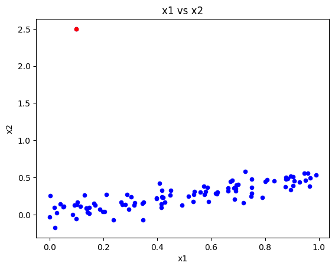

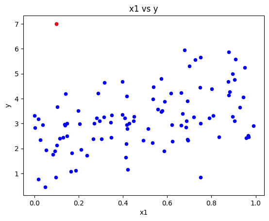

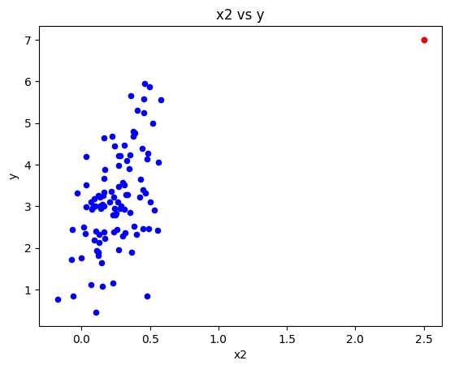

```python
# outlier analysis
new_observation = updated_df.iloc[-1:]
x1_x2 = updated_df.plot(kind='scatter',x='x1',y='x2',color='blue')
new_observation.plot(ax=x1_x2,kind='scatter',x='x1',y='x2',color='red')
plt.title('x1 vs x2')
plt.show()

x1_y = updated_df.plot(kind='scatter',x='x1',y='y',color='blue')
new_observation.plot(ax=x1_y,kind='scatter',x='x1',y='y',color='red')
plt.title('x1 vs y')
plt.show()

x2_y = updated_df.plot(kind='scatter',x='x2',y='y',color='blue')
new_observation.plot(ax=x2_y,kind='scatter',x='x2',y='y',color='red')
plt.title('x2 vs y')
plt.show()
```

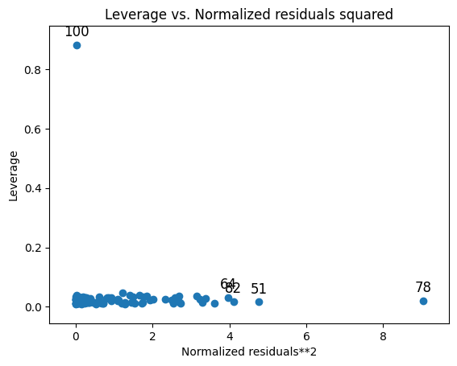

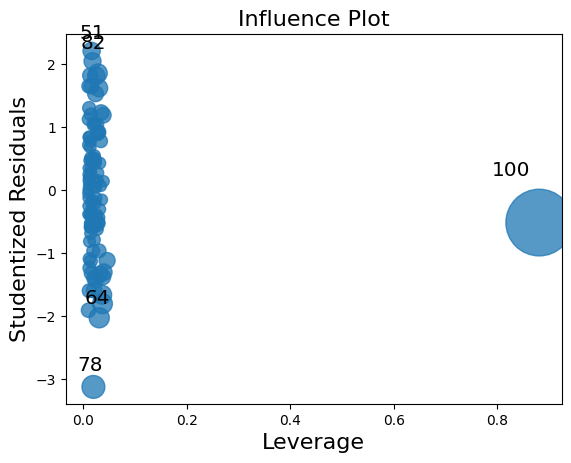

```python
plot_leverage_resid2(combined_model)
plt.show()

sm.graphics.influence_plot(combined_model)
plt.show()
```

## Question 8

It is claimed that in the case of simple linear regression of $Y$ onto $X$, the $R^2$ statistic is equal to the square of the correlation between $X$ and $Y$. Generate some synthetic data and show that this is the case.

link to correlation function: https://numpy.org/doc/stable/reference/generated/numpy.corrcoef.html

```python
# BEGIN SOLUTION
np.random.seed(8)
gen_x = np.random.rand(100)
gen_y = -3 + 3*gen_x + np.random.normal(0,0.3,100)

correlation = np.corrcoef(gen_x, gen_y)[0,1]

gen_X = sm.add_constant(gen_x)
gen_model = sm.OLS(gen_y,gen_X).fit()

formula_r_square = correlation**2
gen_model_r_square = gen_model.rsquared

print(f"R-squared from the formula = {round(formula_r_square,4)} and R-squared from the model = {round(gen_model_r_square,4)}")

if round(formula_r_square,4)==round(gen_model_r_square,4):
    print("\nHence, R-squared is equal to the square of the correlation between X and Y for a simple linear regression of Y onto X")
# END SOLUTION
```

```
R-squared from the formula = 0.8749 and R-squared from the model = 0.8749

Hence, R-squared is equal to the square of the correlation between X and Y for a simple linear regression of Y onto X
```